# Thesis

Minxing Huang

2024-05-03

## load package

```r
library(haven)
library(tidyverse)
library(gtsummary)
library(DescTools)
library(modelsummary)
library(kableExtra)
library(jtools)
```

## import and select data

```r
# import data
drvbp <- read_sas("derivbp.sas7bdat")

# select data
drvbp2 <- drvbp %>%
  dplyr::filter(timept == 3) %>%
  dplyr::select(sex, ethnic, edu, emplst, age, smok, smokavg, ecigavg, cigavg, pipeavg, alc, wine, spirits, beer, caff, caffavg, bl_sbp, bl_dbp, sbpavg, dbpavg, trt)
```

## examine and impute missing data

```r
# examine missing
subset(drvbp2, is.na(sex) == TRUE)
```

```
## # A tibble: 0 × 21
## # ℹ 21 variables: sex <dbl>, ethnic <dbl>, edu <dbl>, emplst <dbl>, age <dbl>,
## #   smok <dbl>, smokavg <dbl>, ecigavg <dbl>, cigavg <dbl>, pipeavg <dbl>,
## #   alc <dbl>, wine <dbl>, spirits <dbl>, beer <dbl>, caff <dbl>,
## #   caffavg <dbl>, bl_sbp <dbl>, bl_dbp <dbl>, sbpavg <dbl>, dbpavg <dbl>,
## #   trt <dbl>
```

```r
subset(drvbp2, is.na(ethnic) == TRUE)
```

```
## # A tibble: 0 × 21
## # ℹ 21 variables: sex <dbl>, ethnic <dbl>, edu <dbl>, emplst <dbl>, age <dbl>,
## #   smok <dbl>, smokavg <dbl>, ecigavg <dbl>, cigavg <dbl>, pipeavg <dbl>,
## #   alc <dbl>, wine <dbl>, spirits <dbl>, beer <dbl>, caff <dbl>,
## #   caffavg <dbl>, bl_sbp <dbl>, bl_dbp <dbl>, sbpavg <dbl>, dbpavg <dbl>,
## #   trt <dbl>
```

```r
subset(drvbp2, is.na(edu) == TRUE)
```

```
## # A tibble: 0 × 21
## # ℹ 21 variables: sex <dbl>, ethnic <dbl>, edu <dbl>, emplst <dbl>, age <dbl>,
## #   smok <dbl>, smokavg <dbl>, ecigavg <dbl>, cigavg <dbl>, pipeavg <dbl>,
## #   alc <dbl>, wine <dbl>, spirits <dbl>, beer <dbl>, caff <dbl>,
## #   caffavg <dbl>, bl_sbp <dbl>, bl_dbp <dbl>, sbpavg <dbl>, dbpavg <dbl>,
## #   trt <dbl>
```

```r
subset(drvbp2, is.na(emplst) == TRUE)
```

```
## # A tibble: 0 × 21
## # ℹ 21 variables: sex <dbl>, ethnic <dbl>, edu <dbl>, emplst <dbl>, age <dbl>,
## #   smok <dbl>, smokavg <dbl>, ecigavg <dbl>, cigavg <dbl>, pipeavg <dbl>,
## #   alc <dbl>, wine <dbl>, spirits <dbl>, beer <dbl>, caff <dbl>,
## #   caffavg <dbl>, bl_sbp <dbl>, bl_dbp <dbl>, sbpavg <dbl>, dbpavg <dbl>,
## #   trt <dbl>
```

```r
subset(drvbp2, is.na(age) == TRUE)
```

```
## # A tibble: 0 × 21
## # ℹ 21 variables: sex <dbl>, ethnic <dbl>, edu <dbl>, emplst <dbl>, age <dbl>,
## #   smok <dbl>, smokavg <dbl>, ecigavg <dbl>, cigavg <dbl>, pipeavg <dbl>,
## #   alc <dbl>, wine <dbl>, spirits <dbl>, beer <dbl>, caff <dbl>,
## #   caffavg <dbl>, bl_sbp <dbl>, bl_dbp <dbl>, sbpavg <dbl>, dbpavg <dbl>,
## #   trt <dbl>
```

```r
subset(drvbp2, is.na(smok) == TRUE)
```

```
## # A tibble: 0 × 21
## # ℹ 21 variables: sex <dbl>, ethnic <dbl>, edu <dbl>, emplst <dbl>, age <dbl>,
## #   smok <dbl>, smokavg <dbl>, ecigavg <dbl>, cigavg <dbl>, pipeavg <dbl>,
## #   alc <dbl>, wine <dbl>, spirits <dbl>, beer <dbl>, caff <dbl>,
## #   caffavg <dbl>, bl_sbp <dbl>, bl_dbp <dbl>, sbpavg <dbl>, dbpavg <dbl>,
## #   trt <dbl>
```

```r
subset(drvbp2, is.na(alc) == TRUE)
```

```
## # A tibble: 0 × 21
## # ℹ 21 variables: sex <dbl>, ethnic <dbl>, edu <dbl>, emplst <dbl>, age <dbl>,
## #   smok <dbl>, smokavg <dbl>, ecigavg <dbl>, cigavg <dbl>, pipeavg <dbl>,
## #   alc <dbl>, wine <dbl>, spirits <dbl>, beer <dbl>, caff <dbl>,
## #   caffavg <dbl>, bl_sbp <dbl>, bl_dbp <dbl>, sbpavg <dbl>, dbpavg <dbl>,
## #   trt <dbl>
```

```r
subset(drvbp2, is.na(caff) == TRUE)
```

```
## # A tibble: 0 × 21
## # ℹ 21 variables: sex <dbl>, ethnic <dbl>, edu <dbl>, emplst <dbl>, age <dbl>,
## #   smok <dbl>, smokavg <dbl>, ecigavg <dbl>, cigavg <dbl>, pipeavg <dbl>,
## #   alc <dbl>, wine <dbl>, spirits <dbl>, beer <dbl>, caff <dbl>,
## #   caffavg <dbl>, bl_sbp <dbl>, bl_dbp <dbl>, sbpavg <dbl>, dbpavg <dbl>,
## #   trt <dbl>
```

```r
subset(drvbp2, is.na(bl_sbp) == TRUE)
```

```
## # A tibble: 0 × 21
## # ℹ 21 variables: sex <dbl>, ethnic <dbl>, edu <dbl>, emplst <dbl>, age <dbl>,
## #   smok <dbl>, smokavg <dbl>, ecigavg <dbl>, cigavg <dbl>, pipeavg <dbl>,
## #   alc <dbl>, wine <dbl>, spirits <dbl>, beer <dbl>, caff <dbl>,
## #   caffavg <dbl>, bl_sbp <dbl>, bl_dbp <dbl>, sbpavg <dbl>, dbpavg <dbl>,
## #   trt <dbl>
```

```r
subset(drvbp2, is.na(bl_dbp) == TRUE)
```

```
## # A tibble: 0 × 21
## # ℹ 21 variables: sex <dbl>, ethnic <dbl>, edu <dbl>, emplst <dbl>, age <dbl>,
## #   smok <dbl>, smokavg <dbl>, ecigavg <dbl>, cigavg <dbl>, pipeavg <dbl>,
## #   alc <dbl>, wine <dbl>, spirits <dbl>, beer <dbl>, caff <dbl>,
## #   caffavg <dbl>, bl_sbp <dbl>, bl_dbp <dbl>, sbpavg <dbl>, dbpavg <dbl>,
## #   trt <dbl>
```

```r
subset(drvbp2, is.na(sbpavg) == TRUE)
```

```
## # A tibble: 3 × 21
##     sex ethnic   edu emplst   age  smok smokavg ecigavg cigavg pipeavg   alc
##   <dbl>  <dbl> <dbl>  <dbl> <dbl> <dbl>   <dbl>   <dbl>  <dbl>   <dbl> <dbl>
## 1     0      1     4      6    54     0      NA      NA     NA      NA     0
## 2     0      2     4      1    53     0      NA      NA     NA      NA     1
## 3     0      3     4      1    54     1      10       0      0       0     0
## # ℹ 10 more variables: wine <dbl>, spirits <dbl>, beer <dbl>, caff <dbl>,
## #   caffavg <dbl>, bl_sbp <dbl>, bl_dbp <dbl>, sbpavg <dbl>, dbpavg <dbl>,
## #   trt <dbl>
```

```r
subset(drvbp2, is.na(dbpavg) == TRUE)
```

```
## # A tibble: 3 × 21
##     sex ethnic   edu emplst   age  smok smokavg ecigavg cigavg pipeavg   alc
##   <dbl>  <dbl> <dbl>  <dbl> <dbl> <dbl>   <dbl>   <dbl>  <dbl>   <dbl> <dbl>
## 1     0      1     4      6    54     0      NA      NA     NA      NA     0
## 2     0      2     4      1    53     0      NA      NA     NA      NA     1
## 3     0      3     4      1    54     1      10       0      0       0     0
## # ℹ 10 more variables: wine <dbl>, spirits <dbl>, beer <dbl>, caff <dbl>,
## #   caffavg <dbl>, bl_sbp <dbl>, bl_dbp <dbl>, sbpavg <dbl>, dbpavg <dbl>,
## #   trt <dbl>
```

```r
subset(drvbp2, is.na(trt) == TRUE)
```

```
## # A tibble: 0 × 21
## # ℹ 21 variables: sex <dbl>, ethnic <dbl>, edu <dbl>, emplst <dbl>, age <dbl>,
## #   smok <dbl>, smokavg <dbl>, ecigavg <dbl>, cigavg <dbl>, pipeavg <dbl>,
## #   alc <dbl>, wine <dbl>, spirits <dbl>, beer <dbl>, caff <dbl>,
## #   caffavg <dbl>, bl_sbp <dbl>, bl_dbp <dbl>, sbpavg <dbl>, dbpavg <dbl>,
## #   trt <dbl>
```

```r
subset(drvbp2, smok == 1 & is.na(smokavg + ecigavg + cigavg + pipeavg) == TRUE)
```

```
## # A tibble: 2 × 21
##     sex ethnic   edu emplst   age  smok smokavg ecigavg cigavg pipeavg   alc
##   <dbl>  <dbl> <dbl>  <dbl> <dbl> <dbl>   <dbl>   <dbl>  <dbl>   <dbl> <dbl>
## 1     1      2     3      3    66     1      NA       5     NA      NA     1
## 2     0      2     4      6    50     1       5       0      0      NA     1
## # ℹ 10 more variables: wine <dbl>, spirits <dbl>, beer <dbl>, caff <dbl>,
## #   caffavg <dbl>, bl_sbp <dbl>, bl_dbp <dbl>, sbpavg <dbl>, dbpavg <dbl>,
## #   trt <dbl>
```

```r
subset(drvbp2, alc == 1 & is.na(wine + spirits + beer) == TRUE)
```

```
## # A tibble: 1 × 21
##     sex ethnic   edu emplst   age  smok smokavg ecigavg cigavg pipeavg   alc
##   <dbl>  <dbl> <dbl>  <dbl> <dbl> <dbl>   <dbl>   <dbl>  <dbl>   <dbl> <dbl>
## 1     1      2     3      3    66     1      NA       5     NA      NA     1
## # ℹ 10 more variables: wine <dbl>, spirits <dbl>, beer <dbl>, caff <dbl>,
## #   caffavg <dbl>, bl_sbp <dbl>, bl_dbp <dbl>, sbpavg <dbl>, dbpavg <dbl>,
## #   trt <dbl>
```

```r
subset(drvbp2, caff == 1 & is.na(caffavg) == TRUE)
```

```
## # A tibble: 0 × 21
## # ℹ 21 variables: sex <dbl>, ethnic <dbl>, edu <dbl>, emplst <dbl>, age <dbl>,
## #   smok <dbl>, smokavg <dbl>, ecigavg <dbl>, cigavg <dbl>, pipeavg <dbl>,
## #   alc <dbl>, wine <dbl>, spirits <dbl>, beer <dbl>, caff <dbl>,
## #   caffavg <dbl>, bl_sbp <dbl>, bl_dbp <dbl>, sbpavg <dbl>, dbpavg <dbl>,
## #   trt <dbl>
```

```r
# impute missing
drvbp2[is.na(drvbp2)] <- 0
```

> No missing data for sex, race, education, employment, age, caffeine, baseline systolic blood pressure, baseline diastolic blood pressure, and study arm. Missing data for 12-week systolic blood pressure and 12-week diastolic blood pressure. Since the amount of missing data is less than 10% (3 observations), we will remove these observations. Imputation needed for smoking and alcohol.

## manipulate data

```r
drvbp3 <- drvbp2 %>%
  dplyr::mutate(sex2 = case_when(sex == 0 ~ "Male",
                                 sex == 1 ~ "Female"),
                ethnic2 = case_when(ethnic == 1 ~ "White",
                                    ethnic == 2 ~ "Black",
                                    ethnic >= 3 & ethnic <= 6 ~ "Hispanic",
                                    ethnic == 14 ~ "Asian"),
                edu2 = case_when(edu == 2 ~ "Less than Grade 9",
                                 edu == 3 ~ "Less than Grade 12",
                                 edu == 4 ~ "High school",
                                 edu == 5 ~ "Undergraduate",
                                 edu == 7 ~ "Technical/Vocational"),
                emplst2 = case_when(emplst == 1 ~ "Full time",
                                    emplst == 2 ~ "Part time",
                                    emplst == 3 ~ "Retired",
                                    emplst == 5 ~ "Homemaker",
                                    emplst == 6 ~ "Unemployed",),
                trt2 = case_when(trt == 1 ~ "LDQT",
                                 trt == 2 ~ "Control"),

                ethnic2 = factor(ethnic2, levels = c("White", "Black", "Hispanic", "Asian")),
                edu2 = factor(edu2, levels = c("Less than Grade 9", "Less than Grade 12", "High school", "Undergraduate", "Technical/Vocational")),
                emplst2 = factor(emplst2, levels = c("Full time", "Part time", "Retired", "Homemaker", "Unemployed")),
                trt2 = factor(trt2, levels = c("LDQT", "Control")),

                smottl = smokavg + ecigavg + cigavg + pipeavg,
                alcttl = wine + spirits + beer,
                cafttl = caffavg) %>%
  dplyr::select(sex2, ethnic2, edu2, emplst2, age, smok, smottl, alc, alcttl, caff, cafttl, bl_sbp, bl_dbp, sbpavg, dbpavg, trt2)
```

## create sample characteristic table

```r
drvbp3 %>%
  dplyr::select(!c(smok, alc, caff, sbpavg, dbpavg)) %>%
  tbl_summary(by = trt2,
              label = list(sex2 ~ "Sex",
                           ethnic2 ~ "Race/Ethnicity",
                           edu2 ~ "Education",
                           emplst2 ~ "Employment",
                           age ~ "Age (year)",
                           smottl ~ "Number of smoking (/day)",
                           alcttl ~ "Number of alcohol drinks (/week)",
                           cafttl ~ "Number of caffeinated drinks (/week)",
                           bl_sbp ~ "Baseline systolic blood pressure (mmHg)",
                           bl_dbp ~ "Baseline diastolic blood pressure (mmHg)"),
              type = list(c(sex2, ethnic2, edu2, emplst2) ~ "categorical",
                          c(age, smottl, alcttl, cafttl, bl_sbp, bl_dbp) ~ "continuous"),
              statistic = list(all_categorical() ~ "{n} ({p}%)",
                               all_continuous() ~ "{median} ({p25}, {p75})"),
              digits = list(all_categorical() ~ 0,
                            all_continuous() ~ 1)) %>%
  add_overall(last = TRUE) %>%
  modify_caption("**Table 1. Baseline Characteristics Overall and by Study Arm (N = 56)**") %>%
  modify_spanning_header(c("stat_1", "stat_2") ~ "**Study Arm**") %>%
  modify_footnote(all_stat_cols() ~ "n (%) for categorical variables, median (interquartile range) for continuous variables")
```

**Table 1. Baseline Characteristics Overall and by Study Arm (N = 56)**

| **Characteristic** | **Study Arm** **LDQT**, N = 30<sup>1</sup> | **Study Arm** **Control**, N = 26<sup>1</sup> | **Overall**, N = 56<sup>1</sup> |  |
| --- | --- | --- | --- | --- |
| Sex |  |  |  |  |
| Female | 15 (50%) | 11 (42%) | 26 (46%) |  |
| Male | 15 (50%) | 15 (58%) | 30 (54%) |  |
| Race/Ethnicity |  |  |  |  |
| White | 3 (10%) | 2 (8%) | 5 (9%) |  |
| Black | 4 (13%) | 7 (27%) | 11 (20%) |  |
| Hispanic | 22 (73%) | 17 (65%) | 39 (70%) |  |
| Asian | 1 (3%) | 0 (0%) | 1 (2%) |  |
| Education |  |  |  |  |
| Less than Grade 9 | 5 (17%) | 5 (19%) | 10 (18%) |  |
| Less than Grade 12 | 6 (20%) | 4 (15%) | 10 (18%) |  |
| High school | 13 (43%) | 8 (31%) | 21 (38%) |  |
| Undergraduate | 5 (17%) | 7 (27%) | 12 (21%) |  |
| Technical/Vocational | 1 (3%) | 2 (8%) | 3 (5%) |  |
| Employment |  |  |  |  |
| Full time | 11 (37%) | 11 (42%) | 22 (39%) |  |
| Part time | 2 (7%) | 5 (19%) | 7 (13%) |  |
| Retired | 2 (7%) | 1 (4%) | 3 (5%) |  |
| Homemaker | 3 (10%) | 3 (12%) | 6 (11%) |  |
| Unemployed | 12 (40%) | 6 (23%) | 18 (32%) |  |
| Age (year) | 49.0 (43.3, 55.5) | 52.5 (41.8, 57.8) | 50.0 (43.0, 57.3) |  |
| Number of smoking (/day) | 0.0 (0.0, 1.8) | 0.0 (0.0, 1.5) | 0.0 (0.0, 2.0) |  |
| Number of alcohol drinks (/week) | 0.0 (0.0, 1.8) | 0.0 (0.0, 0.8) | 0.0 (0.0, 1.3) |  |
| Number of caffeinated drinks (/week) | 2.5 (0.0, 7.0) | 7.0 (3.0, 9.3) | 4.5 (0.8, 7.0) |  |
| Baseline systolic blood pressure (mmHg) | 137.5 (131.0, 145.4) | 139.8 (132.6, 148.5) | 139.0 (132.1, 147.0) |  |
| Baseline diastolic blood pressure (mmHg) | 84.5 (81.0, 89.6) | 88.5 (75.0, 94.4) | 85.3 (79.8, 93.6) |  |

<sup>1</sup> n (%) for categorical variables, median (interquartile range) for continuous variables

## remove missing data

```r
drvbp4 <- subset(drvbp3, sbpavg > 0 & dbpavg > 0)
```

## examine distribution

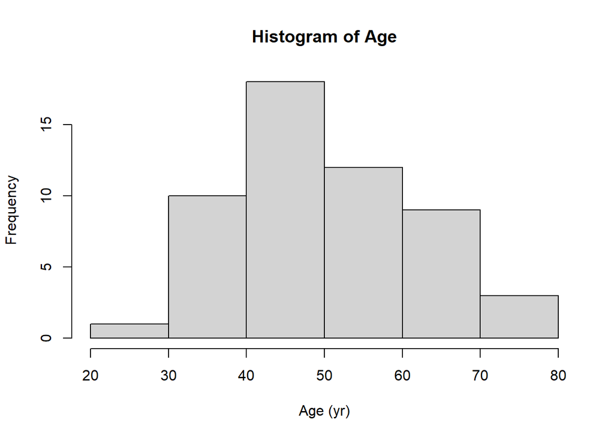

```r
hist(drvbp4$age,
     main = "Histogram of Age",
     xlab = "Age (yr)")
```

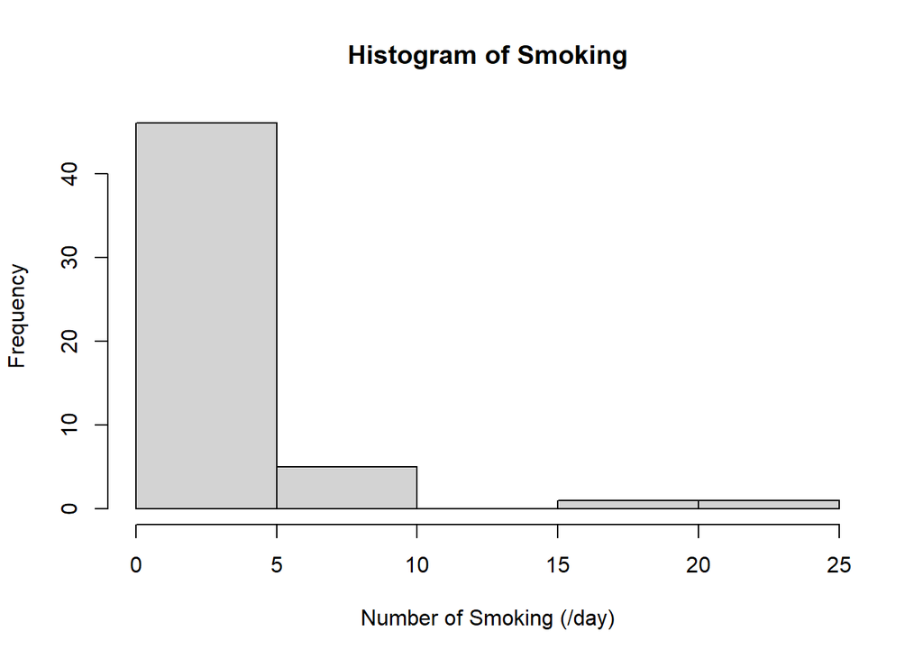

```r
hist(drvbp4$smottl,
     main = "Histogram of Smoking",
     xlab = "Number of Smoking (/day)")
```

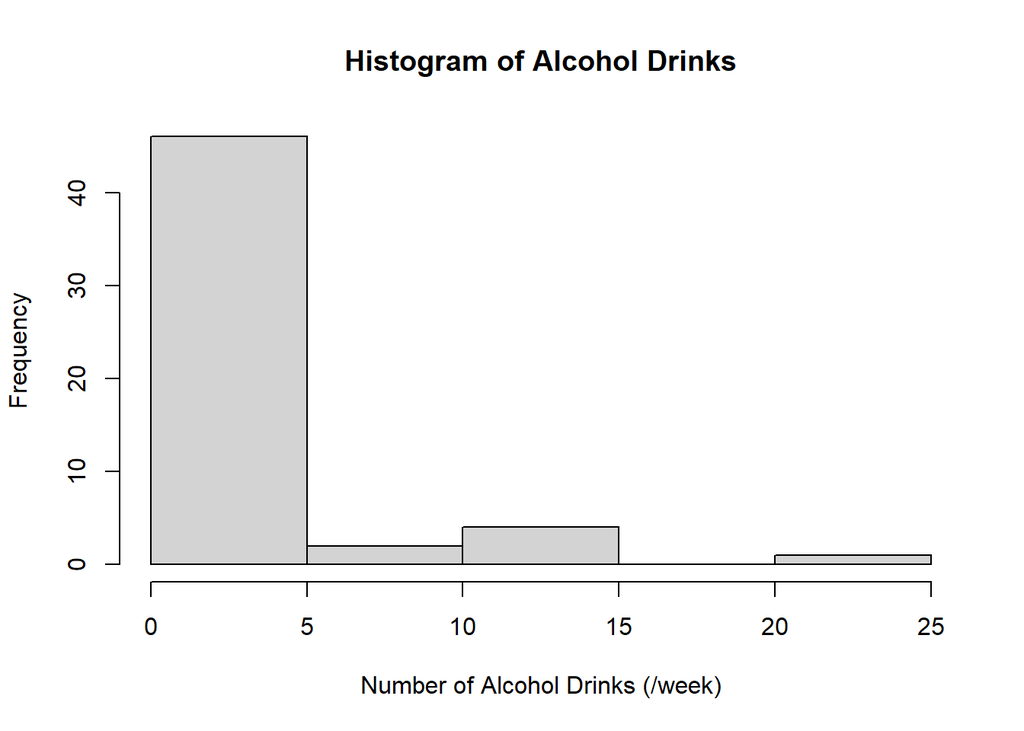

```r
hist(drvbp4$alcttl,
     main = "Histogram of Alcohol Drinks",
     xlab = "Number of Alcohol Drinks (/week)")
```

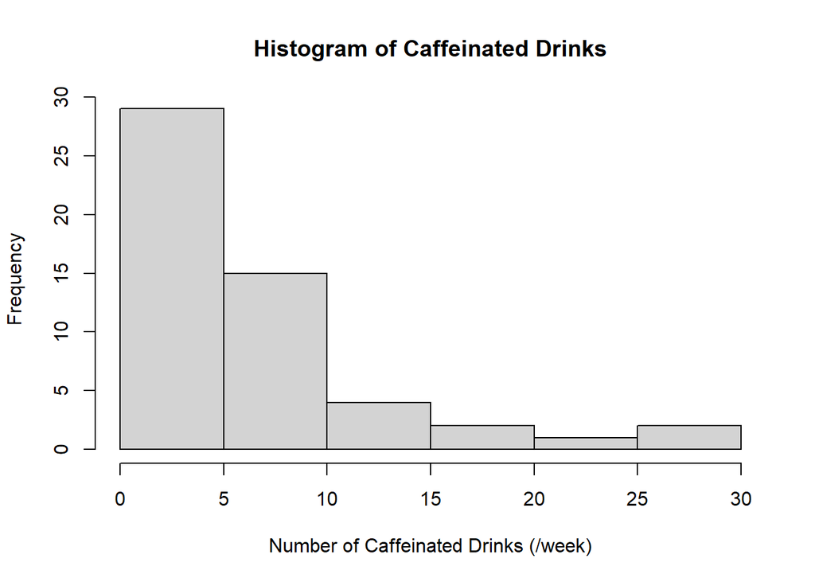

```r
hist(drvbp4$cafttl,
     main = "Histogram of Caffeinated Drinks",
     xlab = "Number of Caffeinated Drinks (/week)")
```

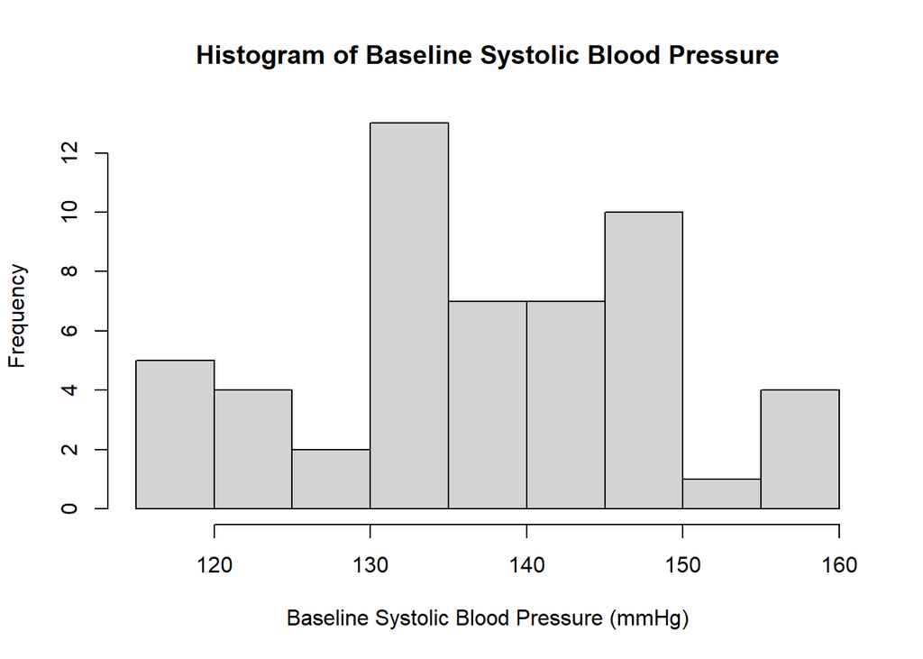

```r
hist(drvbp4$bl_sbp,
     main = "Histogram of Baseline Systolic Blood Pressure",
     xlab = "Baseline Systolic Blood Pressure (mmHg)")
```

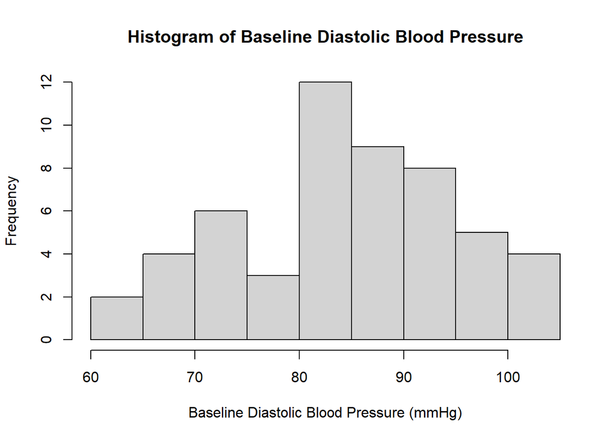

```r
hist(drvbp4$bl_dbp,
     main = "Histogram of Baseline Diastolic Blood Pressure",
     xlab = "Baseline Diastolic Blood Pressure (mmHg)")
```

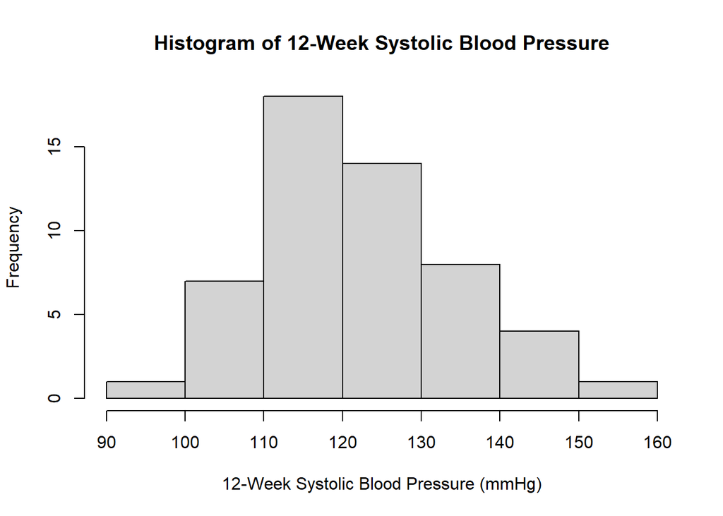

```r
hist(drvbp4$sbpavg,
     main = "Histogram of 12-Week Systolic Blood Pressure",
     xlab = "12-Week Systolic Blood Pressure (mmHg)")
```

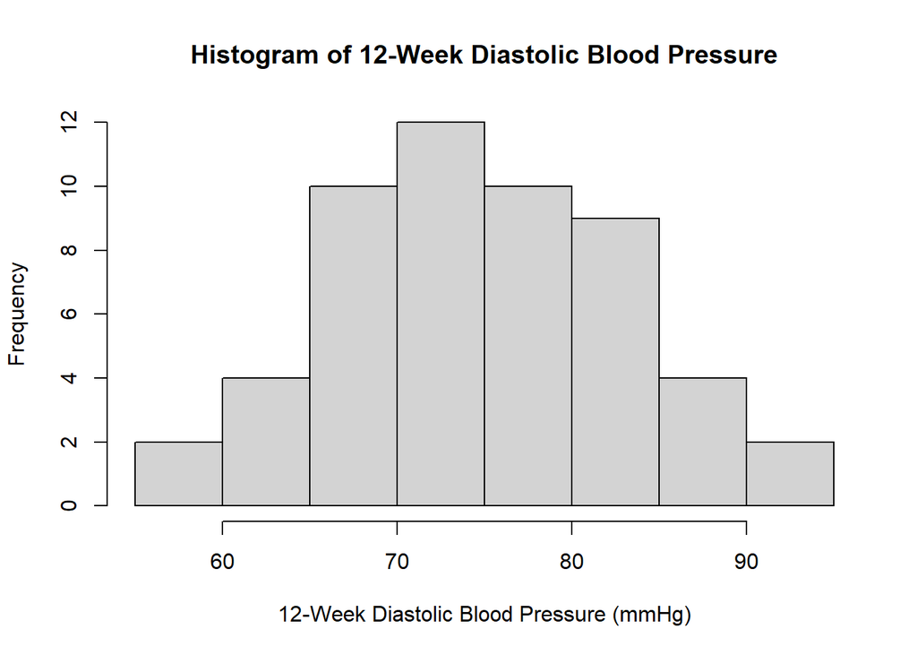

```r
hist(drvbp4$dbpavg,
     main = "Histogram of 12-Week Diastolic Blood Pressure",
     xlab = "12-Week Diastolic Blood Pressure (mmHg)")
```

> Since the distributions of smoking, alcohol, and caffeine are skewed, Spearman’s correlation is needed to examine the pairwise relationship.

## create pairwise scatterplot

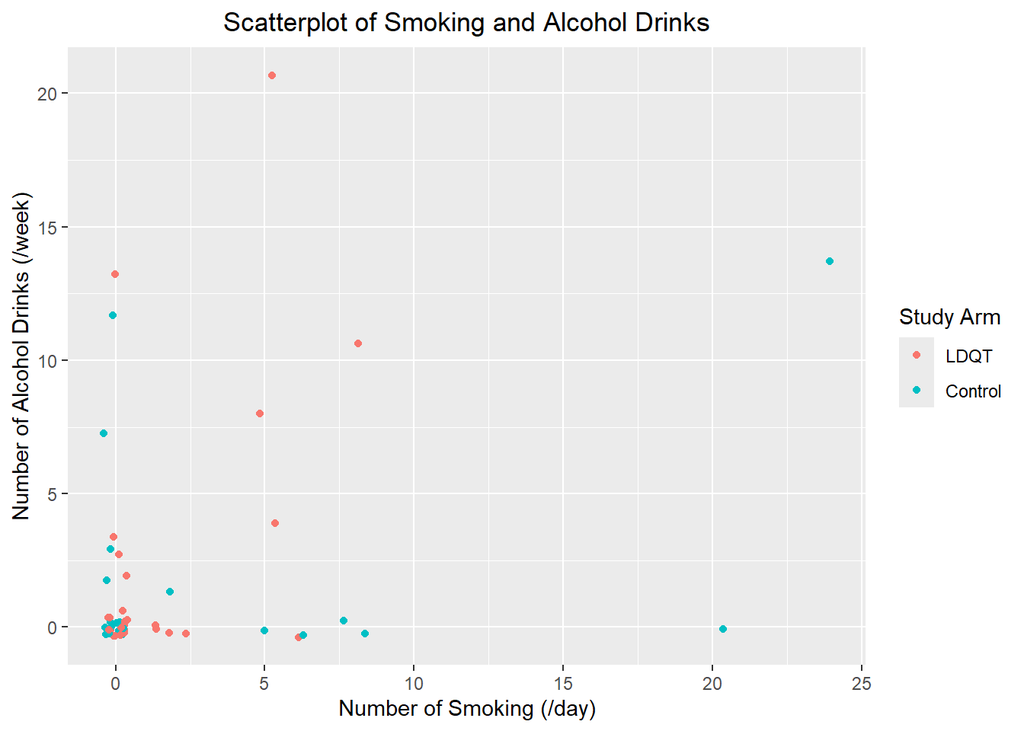

```r
ggplot(drvbp4, aes(x = smottl,
                   y = alcttl,
                   color = trt2)) +
  geom_jitter() +
  labs(title = "Scatterplot of Smoking and Alcohol Drinks",
       x = "Number of Smoking (/day)",
       y = "Number of Alcohol Drinks (/week)",
       color = "Study Arm") +
  theme(plot.title = element_text(hjust = 0.5))
```

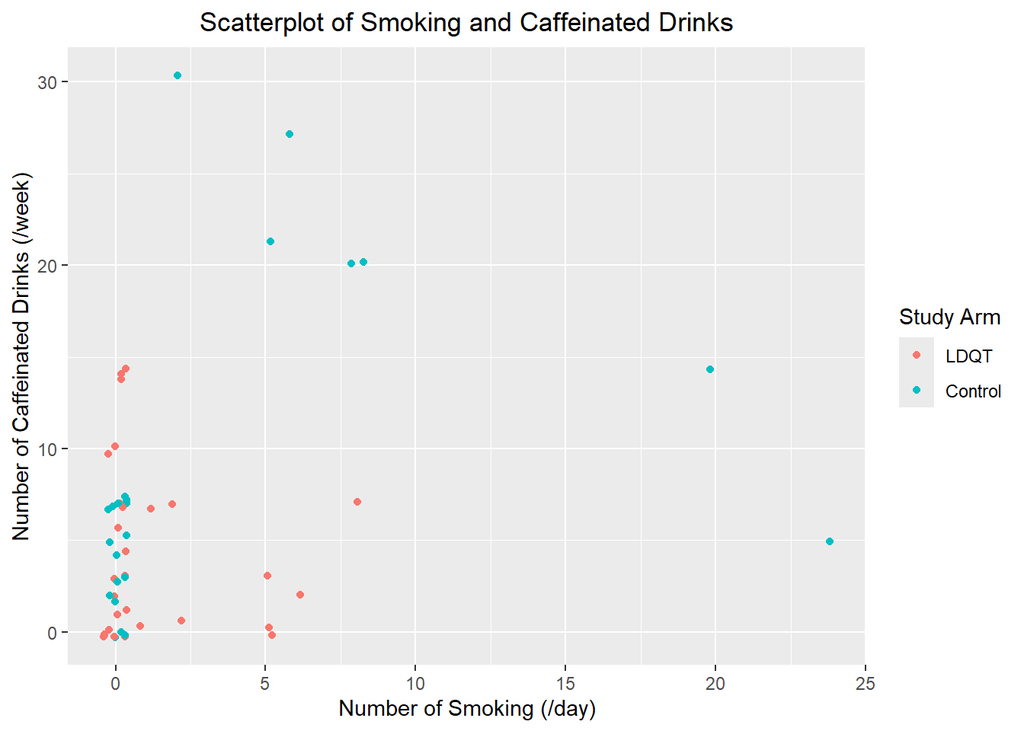

```r
ggplot(drvbp4, aes(x = smottl,
                   y = cafttl,
                   color = trt2)) +
  geom_jitter() +
  labs(title = "Scatterplot of Smoking and Caffeinated Drinks",
       x = "Number of Smoking (/day)",
       y = "Number of Caffeinated Drinks (/week)",
       color = "Study Arm") +
  theme(plot.title = element_text(hjust = 0.5))
```

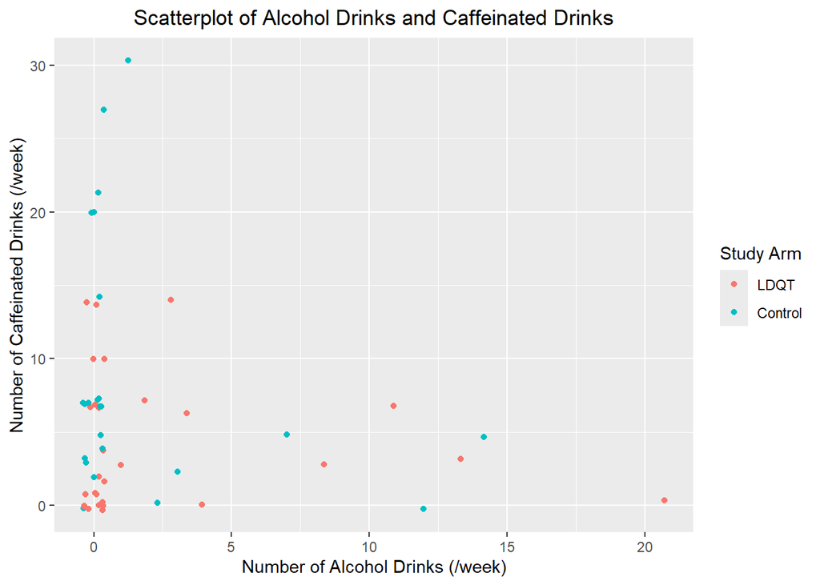

```r
ggplot(drvbp4, aes(x = alcttl,
                   y = cafttl,
                   color = trt2)) +
  geom_jitter() +
  labs(title = "Scatterplot of Alcohol Drinks and Caffeinated Drinks",
       x = "Number of Alcohol Drinks (/week)",
       y = "Number of Caffeinated Drinks (/week)",
       color = "Study Arm") +
  theme(plot.title = element_text(hjust = 0.5))
```

> There is no specific pattern in the pairwise relationship among smoking, alcohol, and caffeine.

## evaluate pairwise relationship

```r
with(drvbp4, SpearmanRho(smottl, alcttl, conf.level = 0.95))
```

```
##         rho      lwr.ci      upr.ci
##  0.19203375 -0.08254458  0.43951434
```

```r
with(drvbp4, SpearmanRho(smottl, cafttl, conf.level = 0.95))
```

```
##         rho      lwr.ci      upr.ci
##  0.25432003 -0.01715289  0.49087083
```

```r
with(drvbp4, SpearmanRho(alcttl, cafttl, conf.level = 0.95))
```

```
##        rho     lwr.ci     upr.ci
## -0.1355161 -0.3914707  0.1399022
```

> Since all confidence intervals include 0, there is no significant pairwise association among smoking, alcohol, and caffeine.

## subset data and create boxplot

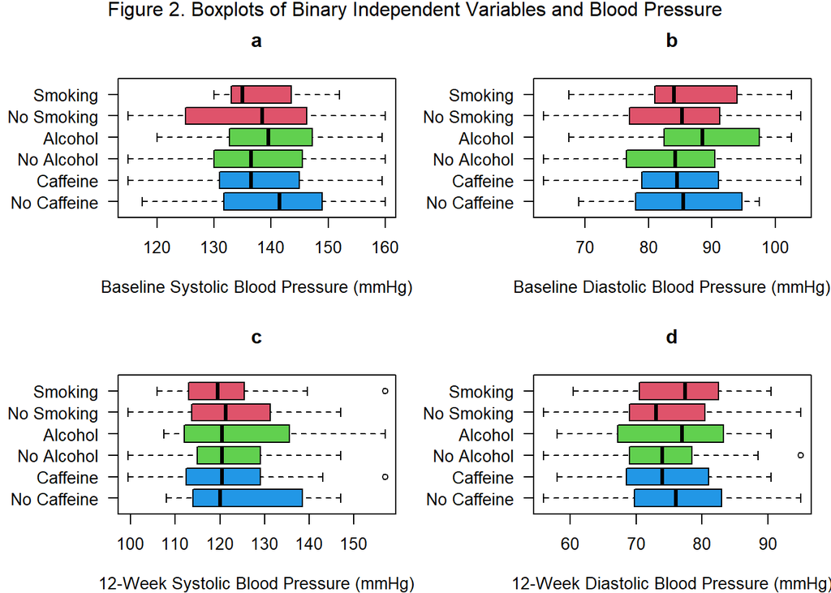

```r
# subset data
drvbp4smo1 <- subset(drvbp4, smok == 1)
drvbp4smo0 <- subset(drvbp4, smok == 0)
drvbp4alc1 <- subset(drvbp4, alc == 1)
drvbp4alc0 <- subset(drvbp4, alc == 0)
drvbp4caf1 <- subset(drvbp4, caff == 1)
drvbp4caf0 <- subset(drvbp4, caff == 0)

# create boxplot
par(las = 1,
    mar = c(4, 6, 4, 1),
    mfrow = c(2, 2))

boxplot(drvbp4caf0$bl_sbp, drvbp4caf1$bl_sbp, drvbp4alc0$bl_sbp, drvbp4alc1$bl_sbp, drvbp4smo0$bl_sbp, drvbp4smo1$bl_sbp,
        main = "a",
        xlab = "Baseline Systolic Blood Pressure (mmHg)",
        names = c("No Caffeine", "Caffeine", "No Alcohol", "Alcohol", "No Smoking", "Smoking"),
        horizontal = TRUE,
        col = rep(c(4, 3, 2), each = 2))
boxplot(drvbp4caf0$bl_dbp, drvbp4caf1$bl_dbp, drvbp4alc0$bl_dbp, drvbp4alc1$bl_dbp, drvbp4smo0$bl_dbp, drvbp4smo1$bl_dbp,
        main = "b",
        xlab = "Baseline Diastolic Blood Pressure (mmHg)",
        names = c("No Caffeine", "Caffeine", "No Alcohol", "Alcohol", "No Smoking", "Smoking"),
        horizontal = TRUE,
        col = rep(c(4, 3, 2), each = 2))
boxplot(drvbp4caf0$sbpavg, drvbp4caf1$sbpavg, drvbp4alc0$sbpavg, drvbp4alc1$sbpavg, drvbp4smo0$sbpavg, drvbp4smo1$sbpavg,
        main = "c",
        xlab = "12-Week Systolic Blood Pressure (mmHg)",
        names = c("No Caffeine", "Caffeine", "No Alcohol", "Alcohol", "No Smoking", "Smoking"),
        horizontal = TRUE,
        col = rep(c(4, 3, 2), each = 2))
boxplot(drvbp4caf0$dbpavg, drvbp4caf1$dbpavg, drvbp4alc0$dbpavg, drvbp4alc1$dbpavg, drvbp4smo0$dbpavg, drvbp4smo1$dbpavg,
        main = "d",
        xlab = "12-Week Diastolic Blood Pressure (mmHg)",
        names = c("No Caffeine", "Caffeine", "No Alcohol", "Alcohol", "No Smoking", "Smoking"),
        horizontal = TRUE,
        col = rep(c(4, 3, 2), each = 2))

mtext("Figure 2. Boxplots of Binary Independent Variables and Blood Pressure",
      side = 3,
      line = -1,
      outer = TRUE)
```

## create scatterplot

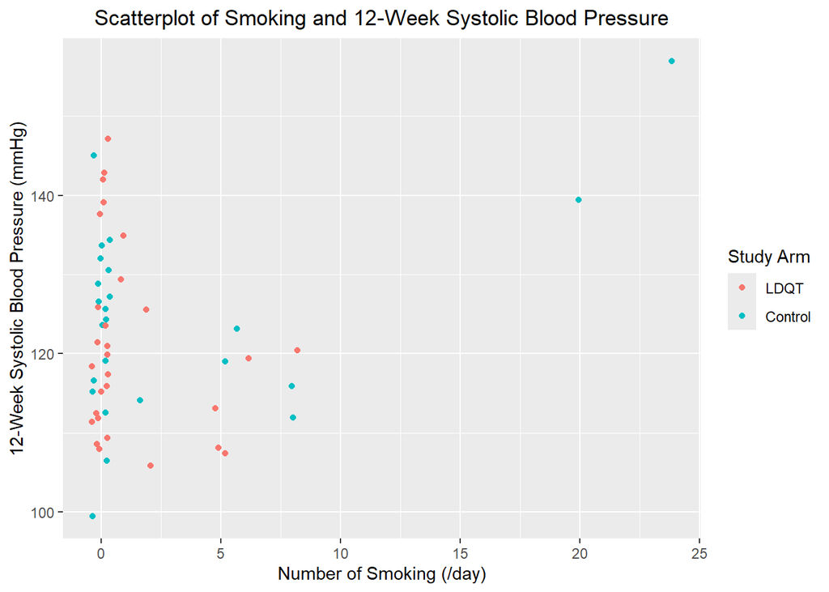

```r
ggplot(drvbp4, aes(x = smottl,
                   y = sbpavg,
                   color = trt2)) +
  geom_jitter() +
  labs(title = "Scatterplot of Smoking and 12-Week Systolic Blood Pressure",
       x = "Number of Smoking (/day)",
       y = "12-Week Systolic Blood Pressure (mmHg)",
       color = "Study Arm") +
  theme(plot.title = element_text(hjust = 0.5))
```

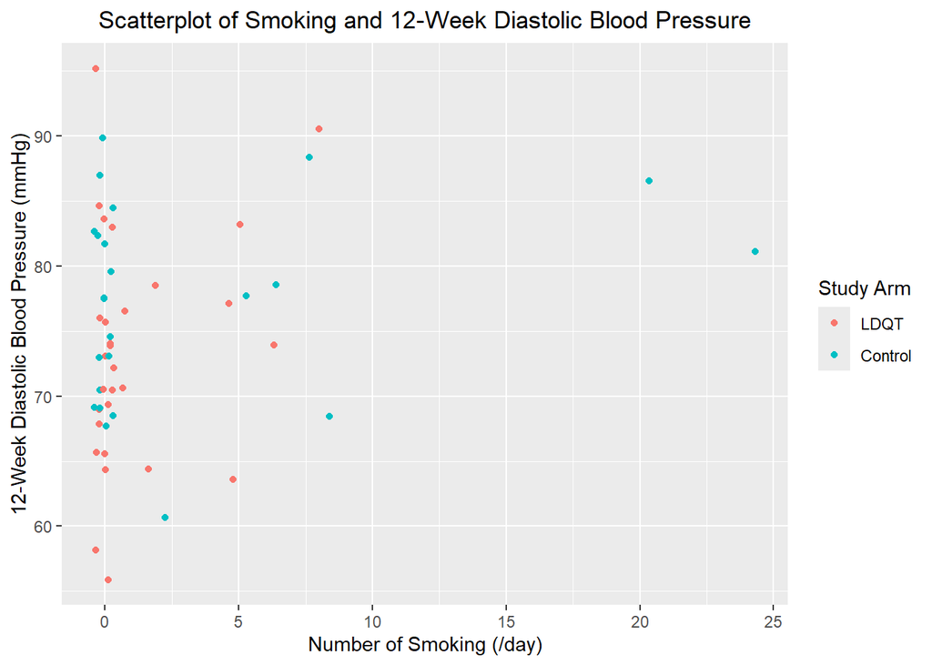

```r
ggplot(drvbp4, aes(x = smottl,
                   y = dbpavg,
                   color = trt2)) +
  geom_jitter() +
  labs(title = "Scatterplot of Smoking and 12-Week Diastolic Blood Pressure",
       x = "Number of Smoking (/day)",
       y = "12-Week Diastolic Blood Pressure (mmHg)",
       color = "Study Arm") +
  theme(plot.title = element_text(hjust = 0.5))
```

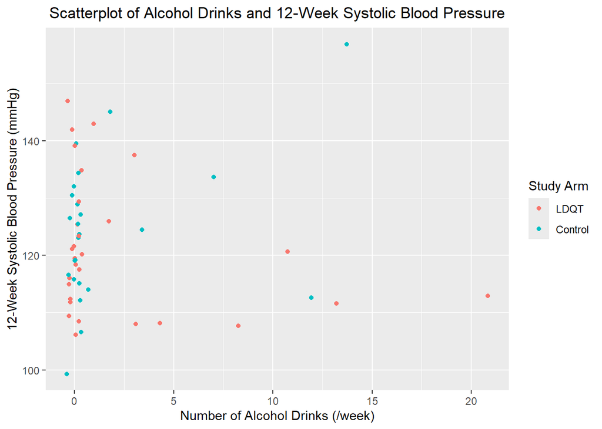

```r
ggplot(drvbp4, aes(x = alcttl,
                   y = sbpavg,
                   color = trt2)) +
  geom_jitter() +
  labs(title = "Scatterplot of Alcohol Drinks and 12-Week Systolic Blood Pressure",
       x = "Number of Alcohol Drinks (/week)",
       y = "12-Week Systolic Blood Pressure (mmHg)",
       color = "Study Arm") +
  theme(plot.title = element_text(hjust = 0.5))
```

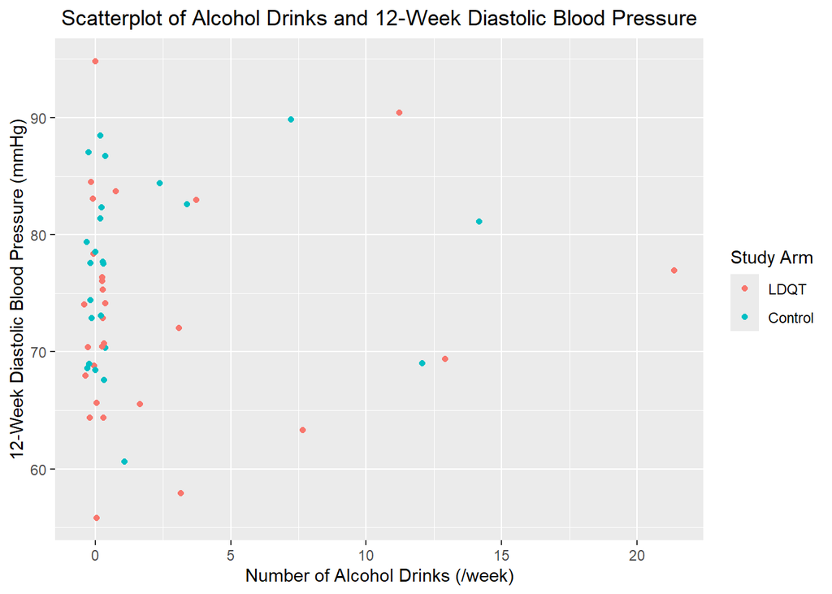

```r
ggplot(drvbp4, aes(x = alcttl,
                   y = dbpavg,
                   color = trt2)) +
  geom_jitter() +
  labs(title = "Scatterplot of Alcohol Drinks and 12-Week Diastolic Blood Pressure",
       x = "Number of Alcohol Drinks (/week)",
       y = "12-Week Diastolic Blood Pressure (mmHg)",
       color = "Study Arm") +
  theme(plot.title = element_text(hjust = 0.5))
```

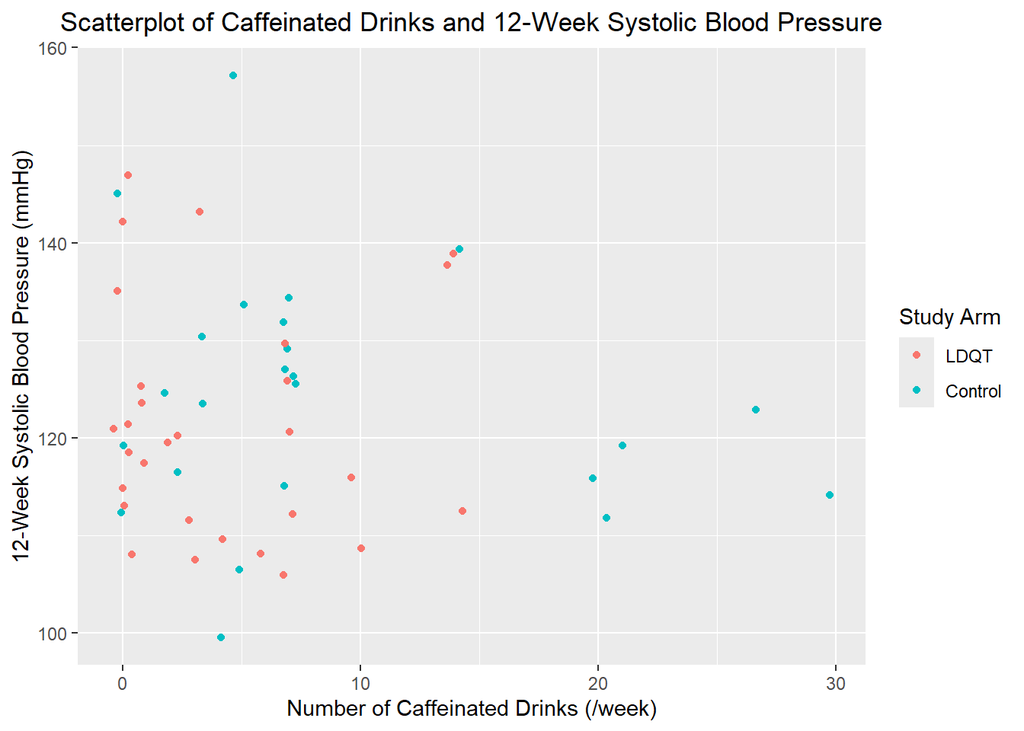

```r
ggplot(drvbp4, aes(x = cafttl,
                   y = sbpavg,
                   color = trt2)) +
  geom_jitter() +
  labs(title = "Scatterplot of Caffeinated Drinks and 12-Week Systolic Blood Pressure",
       x = "Number of Caffeinated Drinks (/week)",
       y = "12-Week Systolic Blood Pressure (mmHg)",
       color = "Study Arm") +
  theme(plot.title = element_text(hjust = 0.5))
```

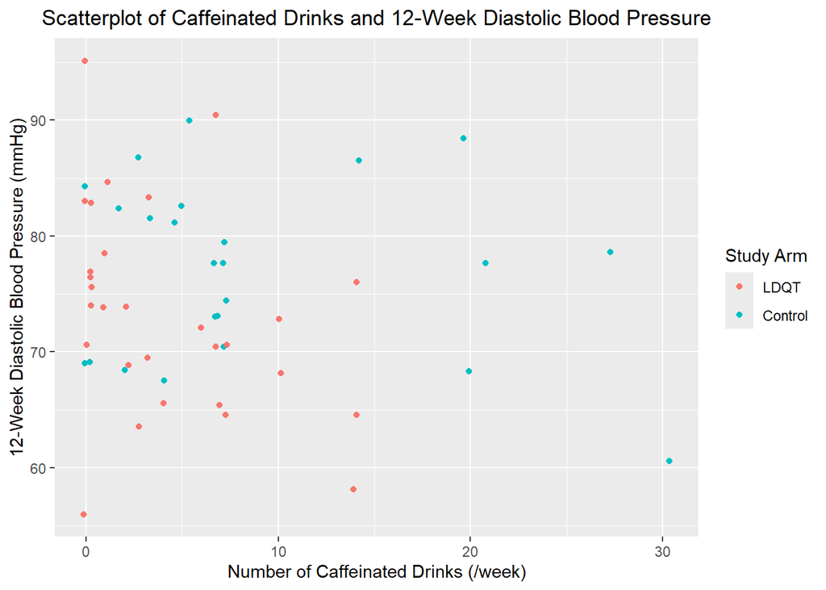

```r
ggplot(drvbp4, aes(x = cafttl,
                   y = dbpavg,
                   color = trt2)) +
  geom_jitter() +
  labs(title = "Scatterplot of Caffeinated Drinks and 12-Week Diastolic Blood Pressure",
       x = "Number of Caffeinated Drinks (/week)",
       y = "12-Week Diastolic Blood Pressure (mmHg)",
       color = "Study Arm") +
  theme(plot.title = element_text(hjust = 0.5))
```

## fit linear regression model

```r
# change factor level
levels(drvbp4$trt2) <- c("Control", "LDQT")

# fit model
fitsbpsmo <- lm(sbpavg ~ smottl + bl_sbp + trt2, data = drvbp4)
fitdbpsmo <- lm(dbpavg ~ smottl + bl_dbp + trt2, data = drvbp4)
fitsbpalc <- lm(sbpavg ~ alcttl + bl_sbp + trt2, data = drvbp4)
fitdbpalc <- lm(dbpavg ~ alcttl + bl_dbp + trt2, data = drvbp4)
fitsbpcaf <- lm(sbpavg ~ cafttl + bl_sbp + trt2, data = drvbp4)
fitdbpcaf <- lm(dbpavg ~ cafttl + bl_dbp + trt2, data = drvbp4)
```

## test model assumption

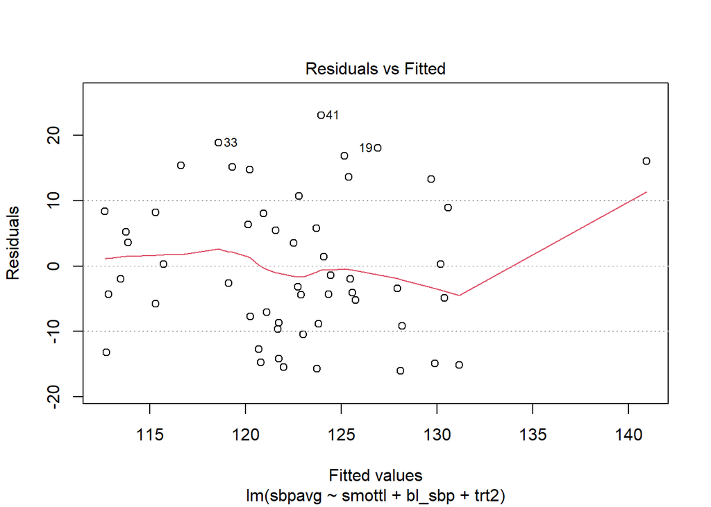

```r
# test linearity and constant variance
plot(fitsbpsmo, which = 1)
abline(h = c(-10, 10),
       col = 8,
       lty = 3)
```

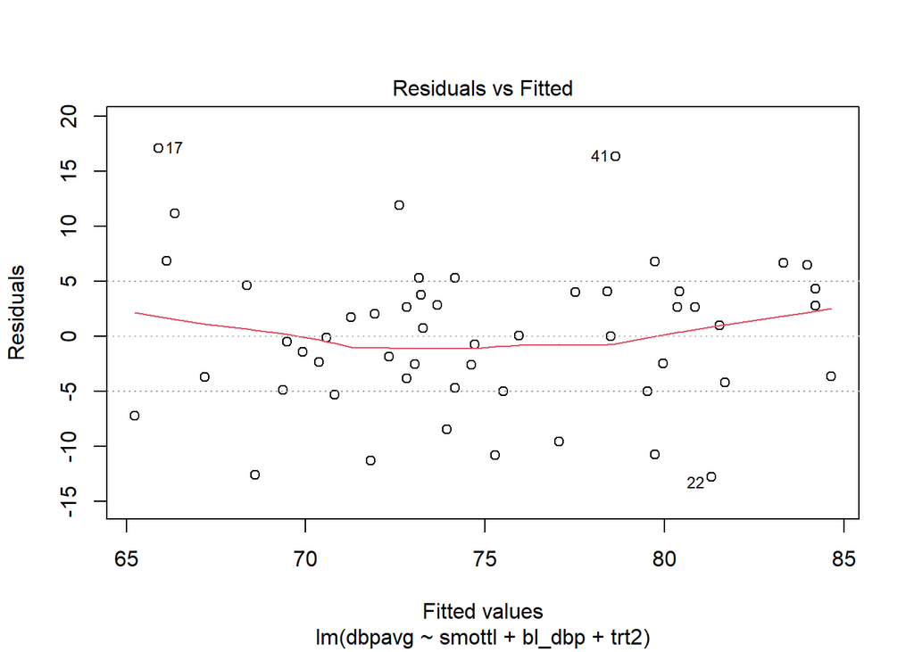

```r
plot(fitdbpsmo, which = 1)
abline(h = c(-5, 5),
       col = 8,
       lty = 3)
```

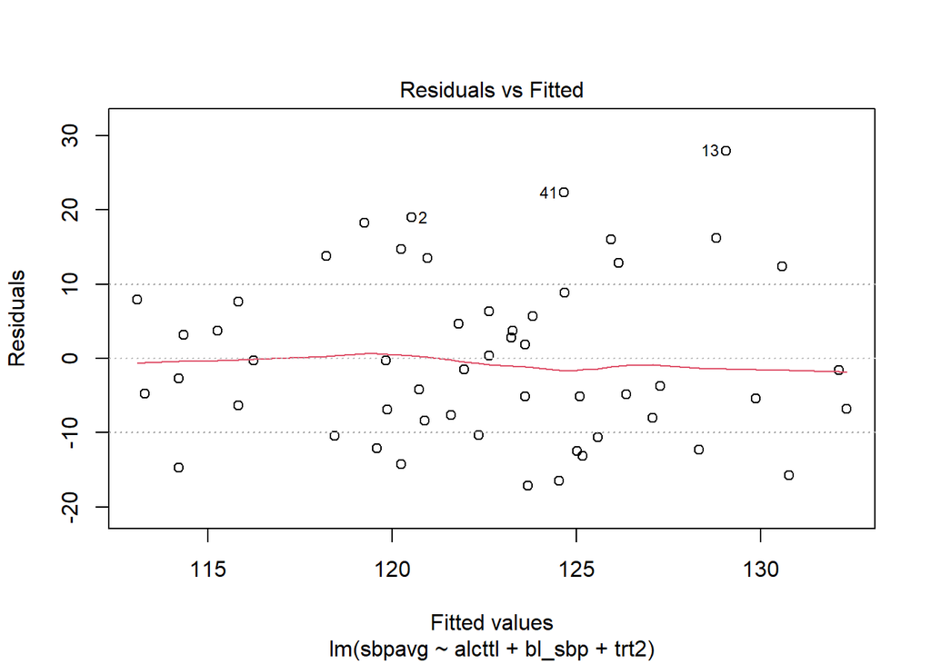

```r
plot(fitsbpalc, which = 1)
abline(h = c(-10, 10),
       col = 8,
       lty = 3)
```

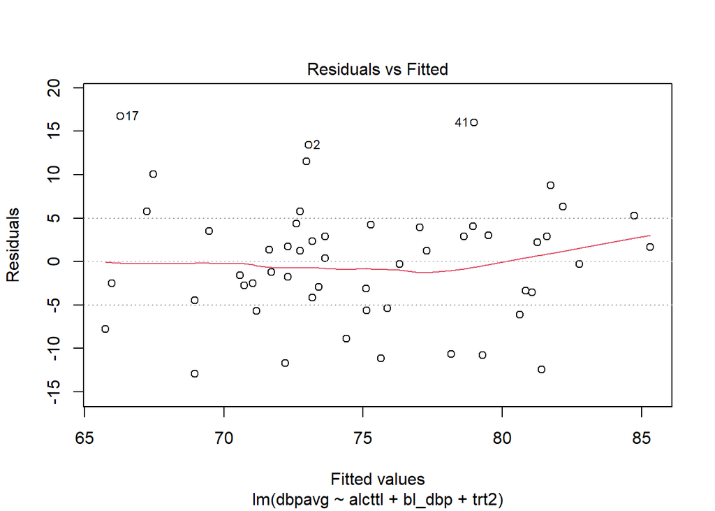

```r
plot(fitdbpalc, which = 1)
abline(h = c(-5, 5),
       col = 8,
       lty = 3)
```

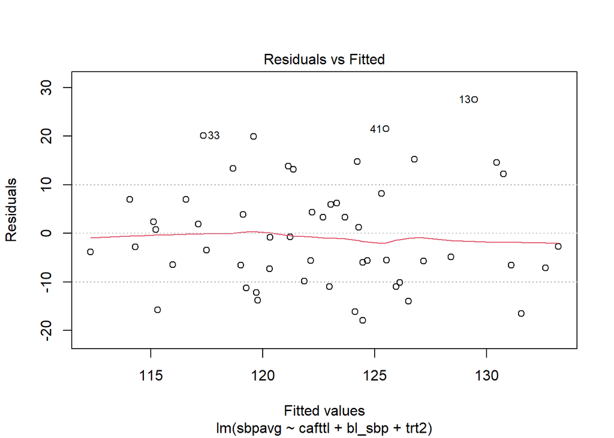

```r
plot(fitsbpcaf, which = 1)
abline(h = c(-10, 10),
       col = 8,
       lty = 3)
```

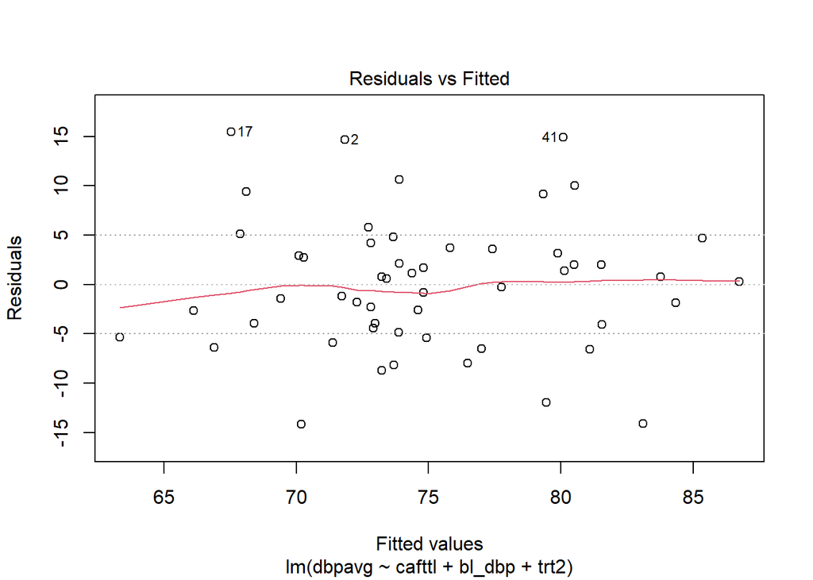

```r
plot(fitdbpcaf, which = 1)
abline(h = c(-5, 5),
       col = 8,
       lty = 3)
```

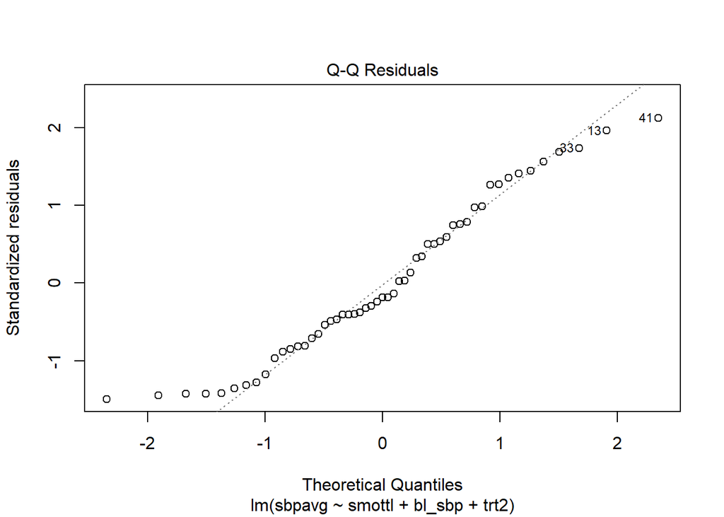

```r
# test normality
plot(fitsbpsmo, which = 2)
```

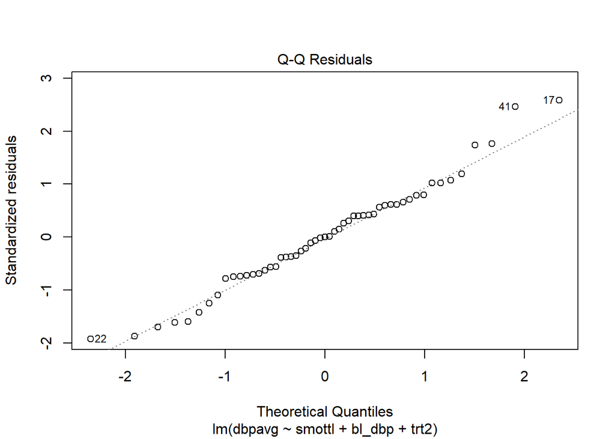

```r
plot(fitdbpsmo, which = 2)
```

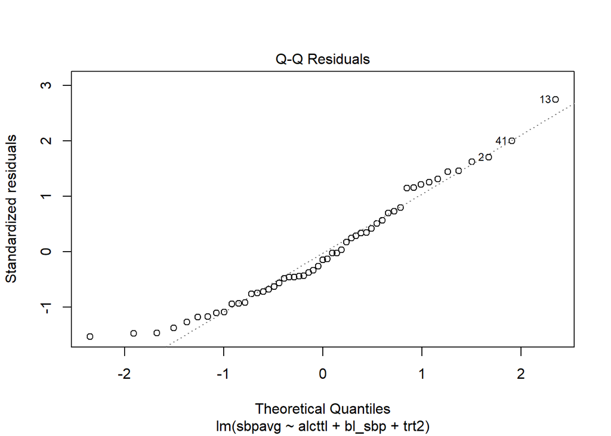

```r
plot(fitsbpalc, which = 2)
```

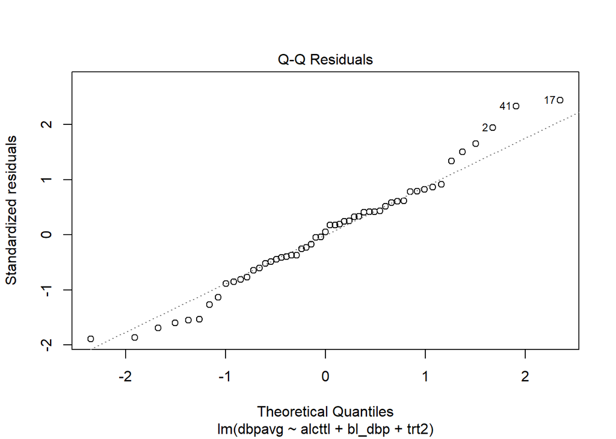

```r
plot(fitdbpalc, which = 2)
```

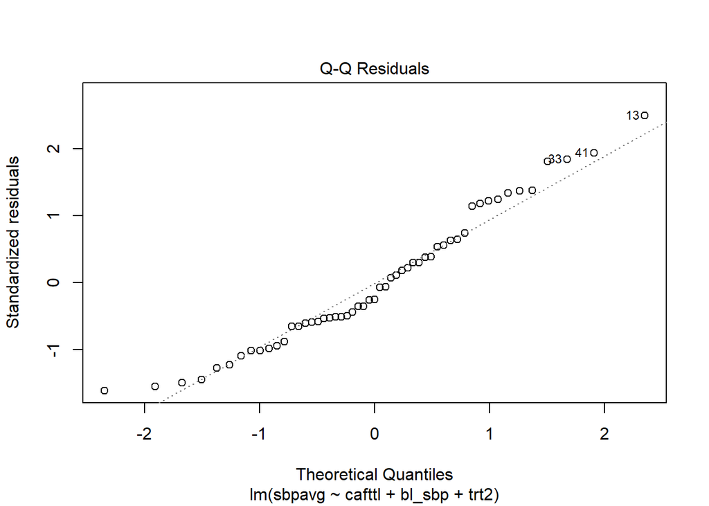

```r
plot(fitsbpcaf, which = 2)
```

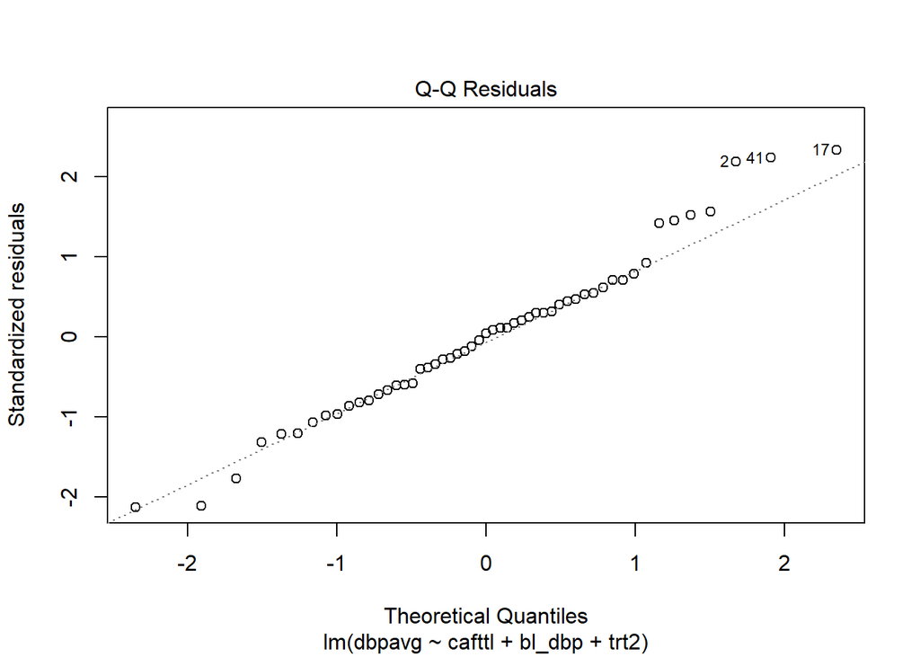

```r
plot(fitdbpcaf, which = 2)
```

> Models dbpsmo, sbpalc, dbpalc, sbpcaf, and dbpcaf meet linearity assumption. Models sbpsmo, dbpsmo, sbpalc, dbpalc, sbpcaf, and dbpcaf meet both constant variance and normality assumptions. To be determined if model sbpsmo has influential points.

## examine influential point

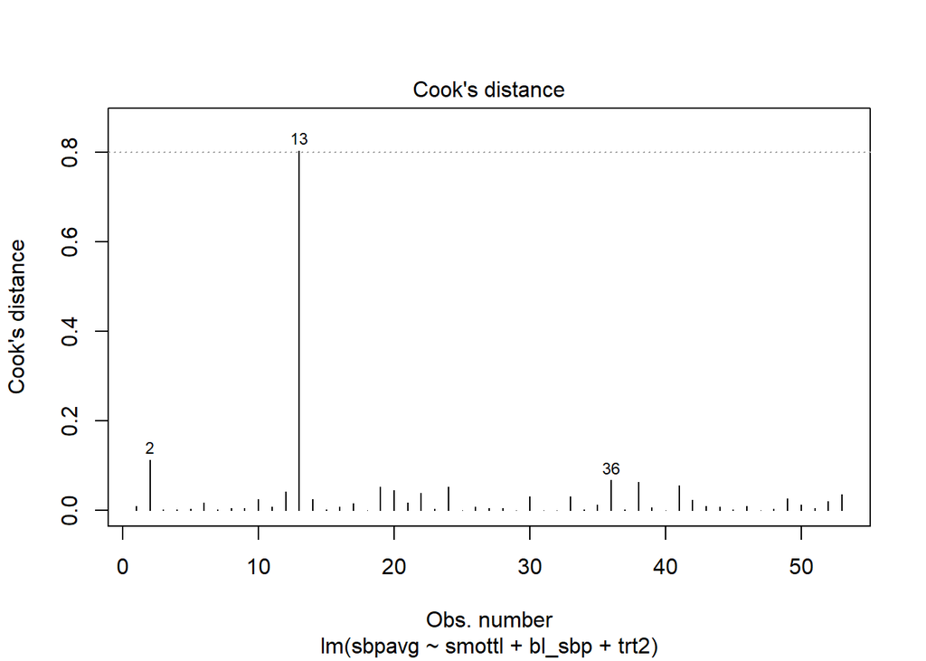

```r
plot(fitsbpsmo, which = 4)
abline(h = 0.8,
       col = 8,
       lty = 3)
```

## summarize model parameter

```r
# examine beta estimate and p-value
summary(fitsbpsmo)
```

```
##
## Call:
## lm(formula = sbpavg ~ smottl + bl_sbp + trt2, data = drvbp4)
##
## Residuals:
##     Min      1Q  Median      3Q     Max
## -16.082  -8.720  -1.961   8.192  23.073
##
## Coefficients:
##             Estimate Std. Error t value Pr(>|t|)
## (Intercept)  64.2058    19.0078   3.378  0.00144 **
## smottl        0.5847     0.3374   1.733  0.08941 .
## bl_sbp        0.4105     0.1380   2.975  0.00453 **
## trt2LDQT      1.3245     3.1378   0.422  0.67480
## ---
## Signif. codes:  0 '***' 0.001 '**' 0.01 '*' 0.05 '.' 0.1 ' ' 1
##
## Residual standard error: 11.13 on 49 degrees of freedom
## Multiple R-squared:  0.2137, Adjusted R-squared:  0.1655
## F-statistic: 4.439 on 3 and 49 DF,  p-value: 0.007747
```

```r
summary(fitdbpsmo)
```

```
##
## Call:
## lm(formula = dbpavg ~ smottl + bl_dbp + trt2, data = drvbp4)
##
## Residuals:
##      Min       1Q   Median       3Q      Max
## -12.7993  -4.1915  -0.0099   4.0896  17.0980
##
## Coefficients:
##             Estimate Std. Error t value Pr(>|t|)
## (Intercept) 35.09560    7.90768   4.438 5.15e-05 ***
## smottl       0.39015    0.20864   1.870   0.0675 .
## bl_dbp       0.44647    0.09234   4.835 1.36e-05 ***
## trt2LDQT     2.67704    1.93965   1.380   0.1738
## ---
## Signif. codes:  0 '***' 0.001 '**' 0.01 '*' 0.05 '.' 0.1 ' ' 1
##
## Residual standard error: 6.887 on 49 degrees of freedom
## Multiple R-squared:  0.3873, Adjusted R-squared:  0.3498
## F-statistic: 10.32 on 3 and 49 DF,  p-value: 2.229e-05
```

```r
summary(fitsbpalc)
```

```
##
## Call:
## lm(formula = sbpavg ~ alcttl + bl_sbp + trt2, data = drvbp4)
##
## Residuals:
##     Min      1Q  Median      3Q     Max
## -17.198  -8.069  -1.625   7.674  27.936
##
## Coefficients:
##             Estimate Std. Error t value Pr(>|t|)
## (Intercept)  63.3688    19.6256   3.229  0.00222 **
## alcttl        0.0221     0.3585   0.062  0.95109
## bl_sbp        0.4213     0.1420   2.967  0.00465 **
## trt2LDQT      2.3947     3.1789   0.753  0.45488
## ---
## Signif. codes:  0 '***' 0.001 '**' 0.01 '*' 0.05 '.' 0.1 ' ' 1
##
## Residual standard error: 11.46 on 49 degrees of freedom
## Multiple R-squared:  0.1656, Adjusted R-squared:  0.1145
## F-statistic: 3.241 on 3 and 49 DF,  p-value: 0.02986
```

```r
summary(fitdbpalc)
```

```
##
## Call:
## lm(formula = dbpavg ~ alcttl + bl_dbp + trt2, data = drvbp4)
##
## Residuals:
##      Min       1Q   Median       3Q      Max
## -12.9474  -4.1861   0.3677   3.9549  16.7297
##
## Coefficients:
##             Estimate Std. Error t value Pr(>|t|)
## (Intercept) 35.48391    8.19916   4.328 7.40e-05 ***
## alcttl       0.04703    0.22468   0.209   0.8351
## bl_dbp       0.44618    0.09637   4.630 2.72e-05 ***
## trt2LDQT     3.42371    1.97365   1.735   0.0891 .
## ---
## Signif. codes:  0 '***' 0.001 '**' 0.01 '*' 0.05 '.' 0.1 ' ' 1
##
## Residual standard error: 7.125 on 49 degrees of freedom
## Multiple R-squared:  0.3442, Adjusted R-squared:  0.304
## F-statistic: 8.571 on 3 and 49 DF,  p-value: 0.0001119
```

```r
summary(fitsbpcaf)
```

```
##
## Call:
## lm(formula = sbpavg ~ cafttl + bl_sbp + trt2, data = drvbp4)
##
## Residuals:
##     Min      1Q  Median      3Q     Max
## -17.976  -7.119  -2.696   6.924  27.528
##
## Coefficients:
##             Estimate Std. Error t value Pr(>|t|)
## (Intercept)  64.9367    19.5249   3.326  0.00168 **
## cafttl       -0.1963     0.2381  -0.824  0.41369
## bl_sbp        0.4163     0.1411   2.950  0.00486 **
## trt2LDQT      3.2731     3.3300   0.983  0.33048
## ---
## Signif. codes:  0 '***' 0.001 '**' 0.01 '*' 0.05 '.' 0.1 ' ' 1
##
## Residual standard error: 11.38 on 49 degrees of freedom
## Multiple R-squared:  0.1769, Adjusted R-squared:  0.1265
## F-statistic: 3.511 on 3 and 49 DF,  p-value: 0.02194
```

```r
summary(fitdbpcaf)
```

```
##
## Call:
## lm(formula = dbpavg ~ cafttl + bl_dbp + trt2, data = drvbp4)
##
## Residuals:
##      Min       1Q   Median       3Q      Max
## -14.1899  -4.4044   0.2719   3.5777  15.4496
##
## Coefficients:
##             Estimate Std. Error t value Pr(>|t|)
## (Intercept) 37.19587    8.00674   4.646 2.58e-05 ***
## cafttl      -0.25370    0.14472  -1.753   0.0859 .
## bl_dbp       0.43992    0.09285   4.738 1.89e-05 ***
## trt2LDQT     4.54162    2.01905   2.249   0.0290 *
## ---
## Signif. codes:  0 '***' 0.001 '**' 0.01 '*' 0.05 '.' 0.1 ' ' 1
##
## Residual standard error: 6.915 on 49 degrees of freedom
## Multiple R-squared:  0.3823, Adjusted R-squared:  0.3445
## F-statistic: 10.11 on 3 and 49 DF,  p-value: 2.703e-05
```

```r
# calculate confidence interval
confint(fitsbpsmo)
```

```
##                   2.5 %      97.5 %
## (Intercept) 26.00822165 102.4032873
## smottl      -0.09337408   1.2627307
## bl_sbp       0.13323420   0.6876812
## trt2LDQT    -4.98121317   7.6301790
```

```r
confint(fitdbpsmo)
```

```
##                   2.5 %     97.5 %
## (Intercept) 19.20452228 50.9866715
## smottl      -0.02913195  0.8094304
## bl_dbp       0.26089911  0.6320390
## trt2LDQT    -1.22081884  6.5749068
```

```r
confint(fitsbpalc)
```

```
##                  2.5 %      97.5 %
## (Intercept) 23.9296637 102.8079676
## alcttl      -0.6982718   0.7424747
## bl_sbp       0.1359185   0.7067712
## trt2LDQT    -3.9936299   8.7829849
```

```r
confint(fitdbpalc)
```

```
##                  2.5 %     97.5 %
## (Intercept) 19.0070778 51.9607457
## alcttl      -0.4044816  0.4985405
## bl_dbp       0.2525192  0.6398396
## trt2LDQT    -0.5424838  7.3898938
```

```r
confint(fitsbpcaf)
```

```
##                  2.5 %      97.5 %
## (Intercept) 25.6998633 104.1734520
## cafttl      -0.6747934   0.2821903
## bl_sbp       0.1327620   0.6999333
## trt2LDQT    -3.4188525   9.9650877
```

```r
confint(fitdbpcaf)
```

```
##                  2.5 %      97.5 %
## (Intercept) 21.1057153 53.28601978
## cafttl      -0.5445250  0.03712725
## bl_dbp       0.2533345  0.62650617
## trt2LDQT     0.4841915  8.59905175
```

> P-value > 0.05 for smoking, alcohol, and caffeine. It indicates that beta estimates for smoking, alcohol, and caffeine are not significantly different from 0. So, there is no statistically significant association between smoking, alcohol, caffeine and 12-week systolic blood pressure, 12-week diastolic blood pressure.

## create linear regression coefficient table

```r
fit <- list("Model 1 (Left) and 2 (Right)" = list("12-Week Systolic Blood Pressure" = fitsbpsmo,
                                                  "12-Week Diastolic Blood Pressure" = fitdbpsmo),
            "Model 3 (Left) and 4 (Right)" = list("12-Week Systolic Blood Pressure" = fitsbpalc,
                                                  "12-Week Diastolic Blood Pressure" = fitdbpalc),
            "Model 5 (Left) and 6 (Right)" = list("12-Week Systolic Blood Pressure" = fitsbpcaf,
                                                  "12-Week Diastolic Blood Pressure" = fitdbpcaf))
fit %>%
  modelsummary(coef_map = c("smottl" = "Smoking",
                            "alcttl" = "Alcohol Drinks",
                            "cafttl" = "Caffeinated Drinks",
                            "bl_sbp" = "Baseline Systolic Blood Pressure",
                            "bl_dbp" = "Baseline Diastolic Blood Pressure",
                            "trt2LDQT" = "LDQT versus Control"),
               estimate = "{estimate} ({conf.low}, {conf.high})",
               fmt = 2,
               statistic = NULL,
               gof_map = NA,
               shape = "rbind") %>%
  add_header_above(c("Table 2. Linear Regression Results" = 3))
```

| Table 2. Linear Regression Results | Table 2. Linear Regression Results 12-Week Systolic Blood Pressure | Table 2. Linear Regression Results 12-Week Diastolic Blood Pressure |
| --- | --- | --- |
| *Model 1 (Left) and 2 (Right)* |  |  |
| Smoking | 0.58 (-0.09, 1.26) | 0.39 (-0.03, 0.81) |
| Baseline Systolic Blood Pressure | 0.41 (0.13, 0.69) |  |
| Baseline Diastolic Blood Pressure |  | 0.45 (0.26, 0.63) |
| LDQT versus Control | 1.32 (-4.98, 7.63) | 2.68 (-1.22, 6.57) |
| *Model 3 (Left) and 4 (Right)* |  |  |
| Alcohol Drinks | 0.02 (-0.70, 0.74) | 0.05 (-0.40, 0.50) |
| Baseline Systolic Blood Pressure | 0.42 (0.14, 0.71) |  |
| Baseline Diastolic Blood Pressure |  | 0.45 (0.25, 0.64) |
| LDQT versus Control | 2.39 (-3.99, 8.78) | 3.42 (-0.54, 7.39) |
| *Model 5 (Left) and 6 (Right)* |  |  |
| Caffeinated Drinks | -0.20 (-0.67, 0.28) | -0.25 (-0.54, 0.04) |
| Baseline Systolic Blood Pressure | 0.42 (0.13, 0.70) |  |
| Baseline Diastolic Blood Pressure |  | 0.44 (0.25, 0.63) |
| LDQT versus Control | 3.27 (-3.42, 9.97) | 4.54 (0.48, 8.60) |

## create linear regression coefficient plot

[output not shown]

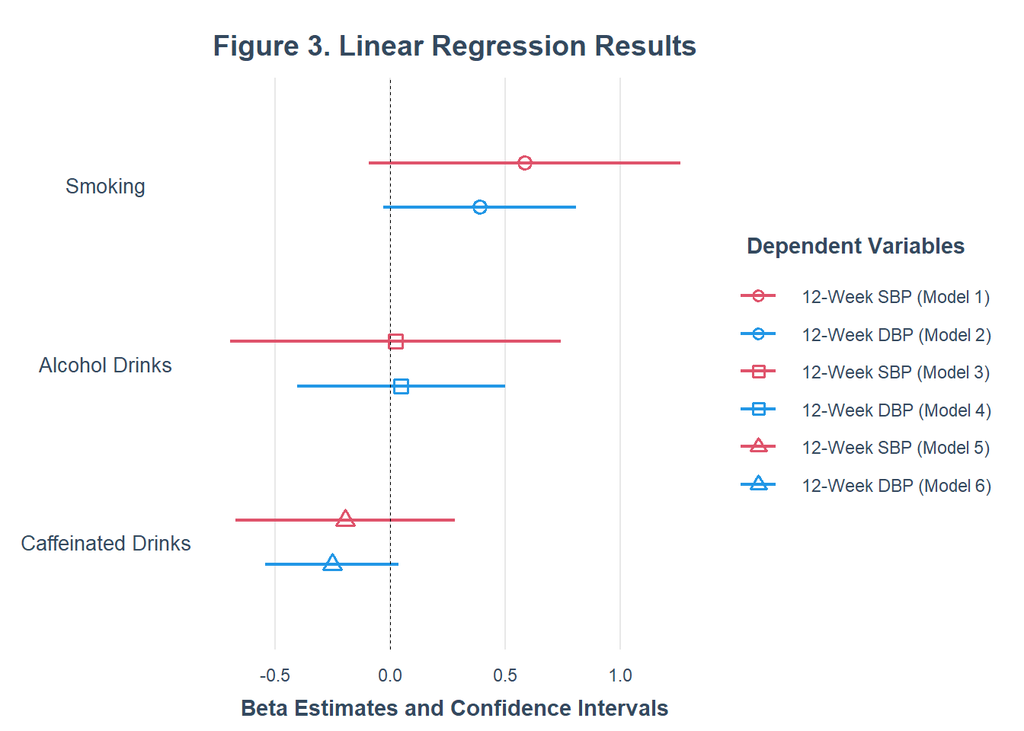

```r
plot_summs(fitsbpsmo, fitdbpsmo, fitsbpalc, fitdbpalc, fitsbpcaf, fitdbpcaf,
           coefs = c("Smoking" = "smottl",
                     "Alcohol Drinks" = "alcttl",
                     "Caffeinated Drinks" = "cafttl"),
           model.names = c("12-Week SBP (Model 1)", "12-Week DBP (Model 2)", "12-Week SBP (Model 3)", "12-Week DBP (Model 4)", "12-Week SBP (Model 5)", "12-Week DBP (Model 6)"),
           legend.title = "Dependent Variables",
           point.shape = rep(c(1, 0, 2), each = 2),
           colors = rep(c(2, 4), 3)) +
  labs(title = "Figure 3. Linear Regression Results",
       x = "Beta Estimates and Confidence Intervals") +
  theme(plot.title = element_text(hjust = 0.5),
        plot.caption = element_text(hjust = 0))
```